# knn

2026-10-05

#This occured because the it contains the knn() function that is needed to perform K-Nearest Neighbors classification.

```r
library(class)
```

#This was used to import the data into R.

```r
UniversalBank <- read.csv("Downloads/UniversalBank.csv")
```

#This helps me make sure the data imported correctly and see what the variables look like.

```r
head(UniversalBank)
```

```
##   ID Age Experience Income ZIP.Code Family CCAvg Education Mortgage
## 1  1  25          1     49    91107      4   1.6         1        0
## 2  2  45         19     34    90089      3   1.5         1        0
## 3  3  39         15     11    94720      1   1.0         1        0
## 4  4  35          9    100    94112      1   2.7         2        0
## 5  5  35          8     45    91330      4   1.0         2        0
## 6  6  37         13     29    92121      4   0.4         2      155
##   Personal.Loan Securities.Account CD.Account Online CreditCard
## 1             0                  1          0      0          0
## 2             0                  1          0      0          0
## 3             0                  0          0      0          0
## 4             0                  0          0      0          0
## 5             0                  0          0      0          1
## 6             0                  0          0      1          0
```

#This tells me how many rows and columns are in the dataset.

```r
dim(UniversalBank)
```

```
## [1] 5000   14
```

#This helps to identify the variables and make sure I used the correct names.

```r
names(UniversalBank)
```

```
##  [1] "ID"                 "Age"                "Experience"
##  [4] "Income"             "ZIP.Code"           "Family"
##  [7] "CCAvg"              "Education"          "Mortgage"
## [10] "Personal.Loan"      "Securities.Account" "CD.Account"
## [13] "Online"             "CreditCard"
```

#This shows the including minimums, maximums, averages, and distributions.

```r
summary(UniversalBank)
```

```
##        ID            Age          Experience       Income          ZIP.Code
##  Min.   :   1   Min.   :23.00   Min.   :-3.0   Min.   :  8.00   Min.   : 9307
##  1st Qu.:1251   1st Qu.:35.00   1st Qu.:10.0   1st Qu.: 39.00   1st Qu.:91911
##  Median :2500   Median :45.00   Median :20.0   Median : 64.00   Median :93437
##  Mean   :2500   Mean   :45.34   Mean   :20.1   Mean   : 73.77   Mean   :93153
##  3rd Qu.:3750   3rd Qu.:55.00   3rd Qu.:30.0   3rd Qu.: 98.00   3rd Qu.:94608
##  Max.   :5000   Max.   :67.00   Max.   :43.0   Max.   :224.00   Max.   :96651
##      Family          CCAvg          Education        Mortgage
##  Min.   :1.000   Min.   : 0.000   Min.   :1.000   Min.   :  0.0
##  1st Qu.:1.000   1st Qu.: 0.700   1st Qu.:1.000   1st Qu.:  0.0
##  Median :2.000   Median : 1.500   Median :2.000   Median :  0.0
##  Mean   :2.396   Mean   : 1.938   Mean   :1.881   Mean   : 56.5
##  3rd Qu.:3.000   3rd Qu.: 2.500   3rd Qu.:3.000   3rd Qu.:101.0
##  Max.   :4.000   Max.   :10.000   Max.   :3.000   Max.   :635.0
##  Personal.Loan   Securities.Account   CD.Account         Online
##  Min.   :0.000   Min.   :0.0000     Min.   :0.0000   Min.   :0.0000
##  1st Qu.:0.000   1st Qu.:0.0000     1st Qu.:0.0000   1st Qu.:0.0000
##  Median :0.000   Median :0.0000     Median :0.0000   Median :1.0000
##  Mean   :0.096   Mean   :0.1044     Mean   :0.0604   Mean   :0.5968
##  3rd Qu.:0.000   3rd Qu.:0.0000     3rd Qu.:0.0000   3rd Qu.:1.0000
##  Max.   :1.000   Max.   :1.0000     Max.   :1.0000   Max.   :1.0000
##    CreditCard
##  Min.   :0.000
##  1st Qu.:0.000
##  Median :0.000
##  Mean   :0.294
##  3rd Qu.:1.000
##  Max.   :1.000
```

#Convert Education into a factor because Education represents categories.

```r
UniversalBank$Education <- factor(UniversalBank$Education)
```

#Using periods in the names makes the variables easier to reference in R.

```r
names(UniversalBank)[names(UniversalBank) == "ZIP Code"] <- "ZIP.Code"
names(UniversalBank)[names(UniversalBank) == "Personal Loan"] <- "Personal.Loan"
names(UniversalBank)[names(UniversalBank) == "Securities Account"] <- "Securities.Account"
names(UniversalBank)[names(UniversalBank) == "CD Account"] <- "CD.Account"
```

#Used to check the column names again to make sure the variables were renamed correctly.

```r
names(UniversalBank)
```

```
##  [1] "ID"                 "Age"                "Experience"
##  [4] "Income"             "ZIP.Code"           "Family"
##  [7] "CCAvg"              "Education"          "Mortgage"
## [10] "Personal.Loan"      "Securities.Account" "CD.Account"
## [13] "Online"             "CreditCard"
```

#This is used by the KNN model to predict whether a customer accepts a personal loan.

```r
X <- model.matrix(
  ~ Age + Experience + Income + Family + CCAvg +
    Education + Mortgage + Securities.Account +
    CD.Account + Online + CreditCard - 1,
  data = UniversalBank
)
```

#This lets me check how the variables, especially Education, were converted.

```r
colnames(X)
```

```
##  [1] "Age"                "Experience"         "Income"
##  [4] "Family"             "CCAvg"              "Education1"
##  [7] "Education2"         "Education3"         "Mortgage"
## [10] "Securities.Account" "CD.Account"         "Online"
## [13] "CreditCard"
```

#This creates outcome variable Y. Personal.Loan is the variable I am trying to predict.The 0 means the customer did not accept the loan and 1 means the customer accepted the loan.

```r
Y <- factor(
  UniversalBank$Personal.Loan,
  levels = c(0, 1)
)
```

#I set a random seed so I get the same training and validation split each time the code is run.

```r
set.seed(123)

train_index <- sample(
  1:nrow(UniversalBank),
  size = 0.60 * nrow(UniversalBank)
)

valid_index <- setdiff(
  1:nrow(UniversalBank),
  train_index
)
```

#Checked how many observations are in the training and validation datasets.This confirms that the data was split correctly.

```r
length(train_index)
```

```
## [1] 3000
```

```r
length(valid_index)
```

```
## [1] 2000
```

#Used to standardize the training data so the variables are on a similar scale.Standardize the validation data using the same mean and standard deviation.

```r
train_means <- apply(X[train_index, ], 2, mean)
train_sds <- apply(X[train_index, ], 2, sd)

train_scaled <- scale(
  X[train_index, ],
  center = train_means,
  scale = train_sds
)

valid_scaled <- scale(
  X[valid_index, ],
  center = train_means,
  scale = train_sds
)
```

#This is information about the customer.This is information on customer’s age, income, family size, education, mortgage, accounts, online banking use, and credit card use.

```r
new_customer <- c(
  Age = 40,
  Experience = 10,
  Income = 84,
  Family = 2,
  CCAvg = 2,
  Education1 = 0,
  Education2 = 1,
  Education3 = 0,
  Mortgage = 0,
  Securities.Account = 0,
  CD.Account = 0,
  Online = 1,
  CreditCard = 1
)
```

#Standardize the new customer’s values using the training data mean and standard deviation so the new customer is on the same scale as the training data.

```r
new_customer_scaled <- (
  new_customer - train_means
) / train_sds
```

#Used to active K-Nearest neighbors.

```r
library(class)
```

#Run the KNN model using k = 1. This predicts the new customer’s Personal Loan outcome based on the single closest customer in the training dataset.

```r
prediction_k1 <- knn(
  train = train_scaled,
  test = matrix(new_customer_scaled, nrow = 1),
  cl = Y[train_index],
  k = 1
)

prediction_k1
```

```
## [1] 0
## Levels: 0 1
```

#Create a sequence of possible k values from 1 through 20.I tested each value to determine which number of neighbors performs best.

```r
k_values <- 1:20

accuracy <- numeric(length(k_values))

for (i in seq_along(k_values)) {

  predictions <- knn(
    train = train_scaled,
    test = valid_scaled,
    cl = Y[train_index],
    k = k_values[i]
  )

  accuracy[i] <- mean(
    predictions == Y[valid_index]
  )
}
```

#I created a data frame showing each k value and its validation accuracy.This makes it easier to compare the performance of the different k values.

```r
k_results <- data.frame(
  k = k_values,
  Accuracy = accuracy
)

k_results
```

```
##     k Accuracy
## 1   1   0.9635
## 2   2   0.9575
## 3   3   0.9585
## 4   4   0.9570
## 5   5   0.9545
## 6   6   0.9525
## 7   7   0.9545
## 8   8   0.9515
## 9   9   0.9495
## 10 10   0.9485
## 11 11   0.9465
## 12 12   0.9460
## 13 13   0.9465
## 14 14   0.9475
## 15 15   0.9435
## 16 16   0.9445
## 17 17   0.9435
## 18 18   0.9445
## 19 19   0.9420
## 20 20   0.9395
```

#Found the k value that produced the highest validation accuracy.This will be used as the best k for the KNN model.

```r
best_k <- k_values[which.max(accuracy)]

best_k
```

```
## [1] 1
```

#I used the best k value to make predictions for the validation dataset.This allowed me to analyze the final selected KNN model.

```r
valid_prediction <- knn(
  train = train_scaled,
  test = valid_scaled,
  cl = Y[train_index],
  k = best_k
)
```

#I created a confusion matrix comparing the actual loan outcomes with the outcomes predicted by the KNN model.In this case, it shows how many customers were classified correctly and incorrectly.

```r
table(
  Actual = Y[valid_index],
  Predicted = valid_prediction
)
```

```
##       Predicted
## Actual    0    1
##      0 1776   22
##      1   51  151
```

#Used the best k value to predict whether the new customer will accept the personal loan.

```r
prediction_best_k <- knn(
  train = train_scaled,
  test = matrix(new_customer_scaled, nrow = 1),
  cl = Y[train_index],
  k = best_k
)

prediction_best_k
```

```
## [1] 0
## Levels: 0 1
```

#Set the seed again so the new data split can be reproduced.I stored the total number of observations in the dataset, randomly select 50% of the observations for the training dataset and I identified all observations that were not placed in the training dataset.

```r
set.seed(123)

n <- nrow(UniversalBank)

train2_index <- sample(
  1:n,
  size = 0.50 * n
)

remaining_index <- setdiff(
  1:n,
  train2_index
)

valid2_index <- sample(
  remaining_index,
  size = 0.30 * n
)

test_index <- setdiff(
  remaining_index,
  valid2_index
)
```

#Checked the number of observations in the training, validation, and test datasets.This confirms that the data was divided into the expected proportions.

```r
length(train2_index)
```

```
## [1] 2500
```

```r
length(valid2_index)
```

```
## [1] 1500
```

```r
length(test_index)
```

```
## [1] 1000
```

#I calculated the mean and standard deviation of each predictor using the new training dataset.

```r
train2_means <- apply(X[train2_index, ], 2, mean)
train2_sds <- apply(X[train2_index, ], 2, sd)

train2_scaled <- scale(
  X[train2_index, ],
  center = train2_means,
  scale = train2_sds
)

valid2_scaled <- scale(
  X[valid2_index, ],
  center = train2_means,
  scale = train2_sds
)

test_scaled <- scale(
  X[test_index, ],
  center = train2_means,
  scale = train2_sds
)
```

#I used leave-one-out cross-validation on the training dataset.This gives me an estimate of how well the KNN model performs on the training data.

```r
train_prediction <- knn.cv(
  train = train2_scaled,
  cl = Y[train2_index],
  k = best_k
)

table(
  Actual = Y[train2_index],
  Predicted = train_prediction
)
```

```
##       Predicted
## Actual    0    1
##      0 2243   28
##      1   83  146
```

#I used the training dataset to predict the outcomes in the validation dataset.The best k value selected earlier is used for the model.

```r
validation_prediction2 <- knn(
  train = train2_scaled,
  test = valid2_scaled,
  cl = Y[train2_index],
  k = best_k
)

table(
  Actual = Y[valid2_index],
  Predicted = validation_prediction2
)
```

```
##       Predicted
## Actual    0    1
##      0 1335   22
##      1   42  101
```

#I used the final KNN model to predict the Personal Loan outcomes for the test dataset.

```r
test_prediction <- knn(
  train = train2_scaled,
  test = test_scaled,
  cl = Y[train2_index],
  k = best_k
)

table(
  Actual = Y[test_index],
  Predicted = test_prediction
)
```

```
##       Predicted
## Actual   0   1
##      0 885   7
##      1  29  79
```

#I plot the validation accuracy for each value of k.This allows me to visually compare the performance of different numbers of neighbors.The highest point on the graph represents the k value with the best validation accuracy.

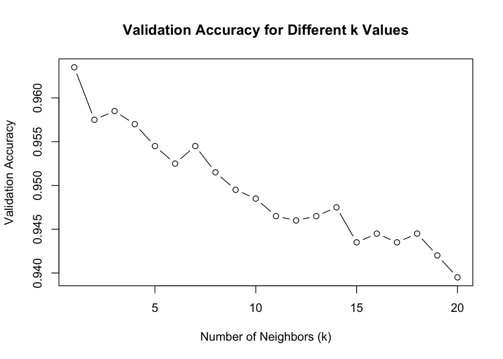

```r
plot(
  k_results$k,
  k_results$Accuracy,
  type = "b",
  xlab = "Number of Neighbors (k)",
  ylab = "Validation Accuracy",
  main = "Validation Accuracy for Different k Values"
)
```